# 2024 Astros Analyst Assessment

Niccolo (Nicco) Jacimovic

2024-07-29

## Question 1: Evaluating Hitting Performance Metrics

In order to assess the value of hitting performance metrics, I would generally follow this approach.

To start, I would clearly define our performance objectives. What specific aspects of hitting performance are we trying to measure and improve?

Next, I would gather comprehensive data on various hitting metrics. This would include traditional statistics like batting average and on-base percentage, as well as more advanced metrics like exit velocity and launch angle.

I would then analyze each metric based on several key criteria:

1. Relevance: Does the metric actually measure what we’re interested in?
2. Consistency: Is the metric stable over time, or does it fluctuate randomly?
3. Predictive power: Does the metric help forecast future performance?
4. Actionability: Can players, coaches and the front office use insights from this metric to improve performance?
5. Simplicity: Is the metric easy to understand and communicate?
6. Context independence: Does the metric hold up across different game situations and environments?

To evaluate these criteria, I would use statistical analyses to examine relationships between metrics and performance outcomes. I would also consult with coaches and players to understand which metrics they find most useful in practice.

Finally, I would synthesize this information to identify a core set of metrics that best meet our criteria. These metrics would form the foundation of our player evaluation and development strategies.

This approach focuses on identifying truly valuable metrics without getting too deep into the specifics of predictive modeling. It balances statistical rigor with practical considerations to ensure we’re using metrics that are both analytically sound and useful in real-world baseball operations.

## Question 2: Ensuring Model Utility on Novel Data

Ensuring the effectiveness of novel data is super critical when developing a model to predict player performance. Here are the key methods I would employ to ensure great model performance:

1. Cross-validation: I would use k-fold cross-validation to assess how well the model generalizes to unseen data. This involves splitting the data into k subsets, training the model on k-1 subsets, and testing it on the remaining subset, repeating this process k times.
2. Train-test split: Before final model evaluation, I would set aside a portion of the data (probably like 20-30%) as a test set, using it only for final model assessment to simulate performance on truly novel data.
3. Regularization techniques: To prevent overfitting, I would apply regularization methods like L1 (Lasso) or L2 (Ridge) regularization, which add penalties for model complexity.
4. Feature selection: I would carefully select features based on their predictive power and domain knowledge, avoiding the inclusion of redundant or irrelevant variables that might lead to overfitting.
5. Ensemble methods: Techniques like Random Forests or Gradient Boosting can help improve generalization by combining multiple models.
6. Monitoring for concept drift: I would implement systems to monitor model performance over time, watching for signs of concept drift where the relationship between features and target variables changes.
7. External validation: When possible, I would test the model on completely separate datasets, such as minor league data or data from other teams (if available), to assess its broader applicability.
8. Bootstrapping: This technique involves repeatedly sampling from the training data with replacement to create multiple datasets, training models on each, and averaging the results to reduce overfitting.
9. Sensitivity analysis: I would perform sensitivity analysis to understand how changes in input variables affect the model’s predictions, ensuring the model behaves logically across a range of inputs.

By using these methods, I would aim to develop a model that not only performs well on historical data but also maintains its predictive power when applied to new, unseen player data in future seasons.

I would also potentially consider time-based validation, given that some baseball performance data is time-series in nature. This involves training the model on earlier seasons and testing it on later seasons to mimic real-world prediction scenarios. This would be primarily for pitching performance, but could be applied to other data points.

## Question 3: Estimating True Exit Speed Skill Level

In order to estimate a hitter’s true exit speed skill level from batted ball data with varying sample sizes, I would follow these general guidelines:

I would first try to apply empirical Bayes estimation. This method would shrink individual estimates towards the overall mean, with the degree of shrinkage inversely proportional to the sample size. It helps balance individual performance with league-wide trends.

I would then calculate credible intervals. Instead of point estimates, I’d provide ranges of plausible true skill levels, with wider intervals for smaller sample sizes to capture the inherit uncertainty.

After that, I would use weighted averages for multi-season data. For hitters with multiple seasons of data, I’d employ a weighted average, giving more weight to recent seasons and those with larger sample sizes.

Lastly, I would try to account for contextual factors. I’d consider influences like ballpark effects, weather conditions, and quality of opposition pitching to refine the estimates.

This approach, in my opinion, balances statistical rigor with practicality, and provides a nuanced view of a hitter’s true exit speed skill while accounting for the challenges posed by varying sample sizes.

## Question 4: Choosing a Designated Hitter

To determine which player would be more valuable as a designated hitter, we need to compare their overall offensive contributions. Let’s look at Force-Field Fred and Long-Ball Larry based on their expected outcomes and use some key offensive metrics to make our decision.

On-Base Percentage (OBP): Force-Field Fred: 1.000 (walks every time) Long-Ball Larry: 0.250 (homers 25% of the time)

Slugging Percentage (SLG): Force-Field Fred: 0.000 (never hits) Long-Ball Larry: 1.000 (0.25 * 4 = 1.000)

On-Base Plus Slugging (OPS): Force-Field Fred: 1.000 (1.000 + 0.000) Long-Ball Larry: 1.250 (0.250 + 1.000)

Weighted On-Base Average (wOBA): Force-Field Fred: 0.690 (wOBA weight for walks) Long-Ball Larry: 0.25 * 2.10 = 0.525 (wOBA weight for HR)

Based on these metrics, I would choose Long-Ball Larry because he has a higher OPS which to me is more valuable than Fred’s ability to get on base every single time. At first, I was convinced that Force-Field Fred would be superior, because he gets on base every PA. His perfect OBP would constantly put pressure on the opposing team, allowing other batters to drive him in. Additionally, I thought that Fred’s consistency would be more beneficial over a full season compared to Larry’s all-or-nothing approach.

However, if we compare just player to player, Long-Ball Larry is expected to produce at least 162 runs by himself (assuming he plays every game, and has 4 PAs), while Force-Field Fred produce literally no runs. Objectively, when specifically comparing only these two players, and include no outside factors, Long-Ball Larry is the better choice.

But Baseball is a team game, and there are ways to use both these player’s drastically different skill sets to significantly improve team’s offenses.

Force-Field Fred should bat first in the line-up. This maximizes the amount of plate appearances he has, which puts him on base the most. This also creates an explosion of offense behind him. Traditionally, your best hitters bat 2,3,4,5. This means every solo home run from hitters in the 2,3, and 4 spots now become 2-run home runs.

Long-Ball Larry should bat 3rd or 4th to effectively use his skill set. He should bat earlier in the line up to take advantage of his ability to hit a home run in 25% of all plate appearances. Now, whoever is on base, now experiences the potential benefit of Larry’s slugging.

The average MLB team generated 4.6 runs/game in 2023, which is 0.511 runs/inning. Doing a simple simulation in R (using probabilities of base runner position, given any random PA (from Baseball-Reference 2023 team batting statistics), also assuming both LBL and FFF get 600 PAs), we see that Long-Ball Larry is expected to produce 277 runs, where as Force Field Fred is expected to generate only 137 runs. That means Long-Ball Larry produces 140 more runs, over double what Force-Field Fred produces.

In the regular season, Long-Ball Larry would be the obvious choice. There is an argument to be made about the playoffs about going with Force-Field Fred, for better field positioning. Since the sample size of the playoffs is much smaller, there is a higher probability that Long-Ball Larry goes cold at a critical time.

```r
knitr::opts_chunk$set(
  echo = TRUE,
  message = FALSE,
  warning = FALSE
)
library(tidyr)
library(dplyr)
library(tidyverse)
```

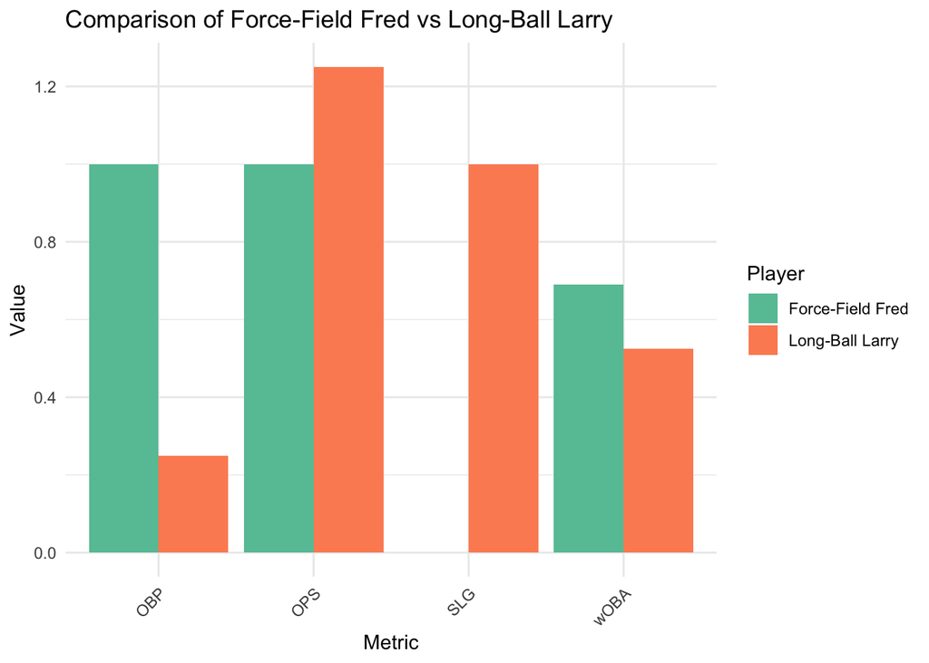

```r
library(ggplot2)

# Set up data
players <- c("Force-Field Fred", "Long-Ball Larry")
obp <- c(1.000, 0.250)
slg <- c(0.000, 1.000)
ops <- c(1.000, 1.250)
woba <- c(0.690, 0.525)

# Create dataframe
df <- data.frame(Player = players, OBP = obp, SLG = slg, OPS = ops, wOBA = woba)

# Reshape the data
df_long <- df %>%
  pivot_longer(cols = c(OBP, SLG, OPS, wOBA),
               names_to = "Metric",
               values_to = "Value")

# Bar plot
ggplot(df_long, aes(x = Metric, y = Value, fill = Player)) +
  geom_bar(stat = "identity", position = position_dodge()) +
  labs(title = "Comparison of Force-Field Fred vs Long-Ball Larry",
       x = "Metric",
       y = "Value") +
  theme_minimal() +
  scale_fill_brewer(palette = "Set2") +
  theme(axis.text.x = element_text(angle = 45, hjust = 1))
```

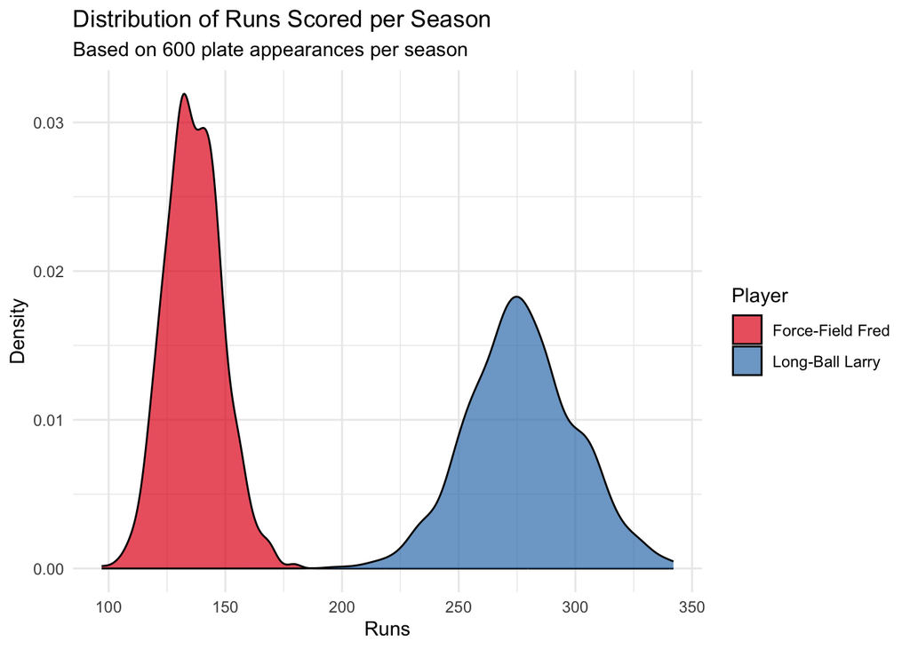

```r
##Simulation
set.seed(123)
simulations <- 1000
pa_per_season <- 600  # Assuming about 150 games with 4 PA per game

simulate_season <- function(player_type, team_obp = 0.320, team_slg = 0.414) {
  runs <- 0
  for (pa in 1:pa_per_season) {
    if (player_type == "Fred") {
      # Fred always walks
      runners <- sample(0:3, 1, prob = c(0.551, 0.2354, 0.1647, 0.0489))  # Estimate baserunners
      runs <- runs + rbinom(1, runners, team_obp)  # Chance to drive in runners
    } else if (player_type == "Larry") {
      if (rbinom(1, 1, 0.25) == 1) {  # 25% chance of homer
        runners <- sample(0:3, 1, prob = c(0.5, 0.25, 0.15, 0.1))  # Estimate baserunners
        runs <- runs + 1 + runners  # HR always scores self + runners
      }
    }
  }
  return(runs)
}

run_simulation <- function(team_obp, team_slg) {
  fred_runs <- replicate(simulations, simulate_season("Fred", team_obp, team_slg))
  larry_runs <- replicate(simulations, simulate_season("Larry", team_obp, team_slg))

  df_runs <- data.frame(
    Player = rep(c("Force-Field Fred", "Long-Ball Larry"), each = simulations),
    Runs = c(fred_runs, larry_runs)
  )

  return(df_runs)
}

# Run simulation with league average OBP and SLG
df_runs_avg <- run_simulation(0.320, 0.414)

# Plot
ggplot(df_runs_avg, aes(x = Runs, fill = Player)) +
  geom_density(alpha = 0.7) +
  labs(title = "Distribution of Runs Scored per Season",
       subtitle = "Based on 600 plate appearances per season",
       x = "Runs",
       y = "Density") +
  theme_minimal() +
  scale_fill_brewer(palette = "Set1")
```

## Question 5: Probability of Recording Fewer than 100 Hits

Given N = 600, we can assume an approximately normal distribution.The batter has a probability of success = 0.3, and a probability of failure = 0.7. Hitting in baseball is fairly binary (you either get on base, or an out). Therefore, the mean should just be n * p, which in this case is .3 * 600, which is equal to 180 hits. The standard deviation is just the sqaure root of the variance of a binary distribution, which is n * p * q, which is 600 * .3 * .7 = 126. The st.dev, therefore, is 126^.5, which is 11.225.

From here, we can standardize the approximate normal curve, and get a z-score. Our goal is to figure out the probability of the batter recording fewer than 100 hits, which would be essentially P(x<100), which is P(z<(100-180)/11.225), which is P(z<-7.111). Without even looking at a Z-table, we know the answer is e) Less than 0.1%. This would be over 7 st.devs away from the mean. 3 st.devs away from the mean basically encompasses 99.7% of the distribution, and we are well above that.

## Question 6: Probability that Player X Throws Left Handed

This is an Bayes’ theorem problem. Given the probabilities from the problem statement P(TL) = 0.11, P(HL) = 0.32, P(HL|TL) = 0.85, we need to determine P(TL|HL). Using Bayes’ theorem, we know that P(TL|HL) = (P(HL|TL) * P(TL))/P(HL), which is just (.85 * .11)/.32 = 0.292.

## Question 7: Lou Rice’s True-Talent Batting Average

Since we are given prior and observed data, we can use Bayesian methods to enhance the quality of our answer. This question seems best tackled (in my opinion) by using a Beta-Binomial approach. Using a normal approximation approach is simpler, but the Beta-Binomial approach encompasses more uncertainty into the probability, and I think it does a better job dealing with tail-end probabilities. The Beta distribution represents our uncertainty about Lou’s true talent level, while the Binomial distribution represents the variability in outcomes for a given true talent level.

The prior belief was that a = 58 and b = 142. However, we observed that Lou went 43/100, which we can use to update a and b such that a = 101 and b = 199. Our new distribution should be Beta(101,199).

In order for Lou to have above a .400 batting avg across 500 PAs, he would need at least 200 hits. Thus, we need to calculate P(X>200 | n = 500, a = 101, b = 199). This comes out to be about 0.0375166.

```r
knitr::opts_chunk$set(
    echo = TRUE,
    message = FALSE,
    warning = FALSE
)
library(extraDistr)  # for the beta-binomial distribution functions

a <- 101
b <- 199
n <- 500
threshold <- 200

prob <- 1 - pbbinom(threshold - 1, n, a, b)
print(prob)
```

```
## [1] 0.0375166
```

## Question 8: Analysis of Batted Ball Data

To determine whether the baseball has been “juiced” in recent years, I conducted a comprehensive analysis of various metrics and factors that could influence hit distances. The investigation spanned from 2015 to 2019, examining not only the direct measures of ball performance but also the contextual factors that might contribute to changes in hitting outcomes.

When looking at hit distance trends, I observed a clear increase in average hit distances over the study period. Mean hit distance rose from 171.0 feet in 2015 to 184.5 feet in 2019. A linear regression analysis confirmed a significant positive trend (p = 0.00853), with an estimated increase of 3.799 feet per year. While this increase is notable, it’s important to consider whether it’s solely attributable to changes in the ball itself. There was a significant jump in distance from 2016 to 2017 (about 10 feet).

I examined several contextual factors that could influence hit distances:

1. Pitch Type: Two-seam fastballs resulted in hit distances about 45.6 feet shorter than four-seam fastballs (p < 2e-16). This significant difference suggests that changes in pitch selection could substantially impact overall hit distances, not the ball (this seems like an obvious point, but still good to note).
2. Batter Handedness: Right-handed batters had significantly shorter hit distances (about 11.2 feet) compared to left-handed batters (p = 0.00727). This indicates that the mix of left- and right-handed batters could affect average hit distances.
3. Hit Direction: There is a significant positive relationship between hit bearing and distance (p = 0.00101), suggesting that pulled balls tend to travel further.
4. Spin Rate: There was a significant positive relationship between spin rate and hit distance (p < 2e-16), indicating that changes in pitching techniques could influence hit distances.

To further investigate different types of hits, I performed a simple clustering analysis, identifying three main groups: “Pull Hitters,” “Up-the-Middle Hitters,” and “Pop-ups/Weak Contact.” This analysis helped me understand how different hitting approaches have evolved over time and their impact on overall distance trends.

I am a strong proponent that the jump in hit distances from 2016 (171.9 feet) to 2017 (182.6 feet) coincides with the “launch angle revolution” in baseball. Many players and teams began adopting approaches focused on optimizing launch angles for increased distance. This shift in hitting strategy, combined with the effects of pitch selection and batter tendencies, provides a plausible explanation for the observed increases without necessitating changes to the ball itself.

Based on my comprehensive analysis, I conclude that there is insufficient statistical and qualitative evidence to support the “juiced ball” theory. The observed increases in hit distances are more likely the result of evolving hitting strategies, changes in pitch selection, and possibly shifts in the types of players coming to the plate. The game of baseball is constantly evolving, and these changes appear to be driving the trends we’re seeing rather than fundamental alterations to the ball.

While the allure of a “juiced ball” narrative is compelling, the data points to a more nuanced reality: baseball is changing, but through the collective adaptations of players and strategies rather than through alterations to the ball itself.

```r
knitr::opts_chunk$set(
    echo = TRUE,
    message = FALSE,
    warning = FALSE
)
## Ball Defect Analysis
# Load required libraries
library(tidyverse)
library(lubridate)
library(ggplot2)
library(car)
library(readr)
library(gridExtra)
library(broom)
library(knitr)
library(scales)
library(cluster)
library(factoextra)

# Load the data
df <- read_csv("data_sample.csv")

# Data preprocessing 1
preprocess_data <- function(df) {
  df %>%
    mutate(
      date = ymd(paste(year, month, "01", sep = "-")),
      across(c(release_speed, plate_speed, hit_exit_speed, hit_spinrate,
               hit_vertical_angle, hit_bearing, hit_distance), as.numeric),
      season = case_when(
        month %in% c(3, 4, 5) ~ "Spring",
        month %in% c(6, 7, 8) ~ "Summer",
        month %in% c(9, 10) ~ "Fall"
      )
    )
}

df <- preprocess_data(df)

# Exploratory Data Analysis
perform_eda <- function(df) {
  print(summary(df))
  print(df %>% group_by(year) %>% summarise(mean_hit_distance = mean(hit_distance, na.rm = TRUE)))
}

#Plots
plot_trends <- function(df) {
  # Hit Distance Over Time
  p1 <- ggplot(df, aes(x = date, y = hit_distance)) +
    geom_point(alpha = 0.1, color = "darkblue") +
    geom_smooth(method = "loess", se = FALSE, color = "red") +
    labs(title = "Hit Distance Over Time",
         x = "Date", y = "Hit Distance (feet)",
         caption = "Smoothed trend line in red") +
    theme_minimal() +
    theme(plot.title = element_text(hjust = 0.5, face = "bold"))

  # Exit Velocity vs Distance by Year
  p2 <- ggplot(df, aes(x = hit_exit_speed, y = hit_distance, color = factor(year))) +
    geom_point(alpha = 0.3) +
    geom_smooth(method = "lm", se = FALSE) +
    labs(title = "Exit Velocity vs Hit Distance",
         x = "Exit Velocity (mph)", y = "Hit Distance (feet)",
         color = "Year") +
    theme_minimal() +
    theme(plot.title = element_text(hjust = 0.5, face = "bold"),
          legend.position = "bottom")

  # Launch Angle Distribution by Year
  p3 <- ggplot(df, aes(x = hit_vertical_angle, fill = factor(year))) +
    geom_density(alpha = 0.7) +
    labs(title = "Launch Angle Distribution by Year",
         x = "Launch Angle (degrees)", y = "Density",
         fill = "Year") +
    theme_minimal() +
    theme(plot.title = element_text(hjust = 0.5, face = "bold"),
          legend.position = "bottom")

  # Home Run Rate by Year
  hr_rate <- df %>%
    group_by(year) %>%
    summarize(hr_rate = mean(event_result == "home_run", na.rm = TRUE))

  p4 <- ggplot(hr_rate, aes(x = factor(year), y = hr_rate)) +
    geom_bar(stat = "identity", fill = "darkgreen") +
    labs(title = "Home Run Rate by Year",
         x = "Year", y = "Home Run Rate") +
    theme_minimal() +
    theme(plot.title = element_text(hjust = 0.5, face = "bold")) +
    scale_y_continuous(labels = percent)

  # Arrange plots
  grid.arrange(p1, p2, p3, p4, ncol = 2)
}

# New analyses
additional_analyses <- function(df) {
  # Seasonal analysis
  season_model <- lm(hit_distance ~ year + season, data = df)
  print("Seasonal Effect on Hit Distance:")
  print(summary(season_model))

  # Pitch type analysis
  pitch_type_model <- lm(hit_distance ~ year + pitch_type, data = df)
  print("Pitch Type Effect on Hit Distance:")
  print(summary(pitch_type_model))

  # Spin rate analysis
  spin_rate_model <- lm(hit_distance ~ year + hit_spinrate, data = df)
  print("Spin Rate Effect on Hit Distance:")
  print(summary(spin_rate_model))

  # Pitcher type analysis
  pitcher_type_model <- lm(hit_distance ~ year + pitcher_throws, data = df)
  print("Pitcher Type Effect on Hit Distance:")
  print(summary(pitcher_type_model))

  # Batter side analysis
  batter_side_model <- lm(hit_distance ~ year + bat_side, data = df)
  print("Batter Side Effect on Hit Distance:")
  print(summary(batter_side_model))

  # Batter bearing analysis
  batter_bearing_model <- lm(hit_distance ~ year + hit_bearing, data = df)
  print("Batter Bearing Effect on Hit Distance:")
  print(summary(batter_bearing_model))

  # Visualization of hit distance by pitch type over years
  p_pitch_type <- ggplot(df, aes(x = factor(year), y = hit_distance, fill = pitch_type)) +
    geom_boxplot() +
    labs(title = "Hit Distance by Pitch Type Over Years",
         x = "Year", y = "Hit Distance (feet)",
         fill = "Pitch Type") +
    theme_minimal()

  print(p_pitch_type)
}

# Clustering analysis
cluster_analysis <- function(df) {
  # Select relevant numeric variables for clustering
  cluster_data <- df %>%
    select(hit_distance, hit_exit_speed, hit_bearing, hit_vertical_angle) %>%
    na.omit()

  # Normalize the data
  cluster_data_normalized <- scale(cluster_data)

  # Perform k-means clustering
  set.seed(123)
  kmeans_result <- kmeans(cluster_data_normalized, centers = 3)

  # Add cluster assignments to the original data
  df$cluster <- kmeans_result$cluster[match(1:nrow(df), as.numeric(rownames(cluster_data)))]

  # Define cluster labels
  cluster_labels <- c("Pull Hitters", "Up-the-Middle Hitters", "Pop-ups/Weak Contact")

  # Assign labels to clusters based on their characteristics
  cluster_centers <- kmeans_result$centers
  cluster_assignment <- order(abs(cluster_centers[, "hit_bearing"]), decreasing = TRUE)
  cluster_names <- cluster_labels[cluster_assignment]

  # Create a named vector for easy mapping
  cluster_name_map <- setNames(cluster_names, 1:3)

  # Add cluster names to the dataframe
  df$cluster_name <- cluster_name_map[as.character(df$cluster)]

  # Visualize clusters
  p1 <- fviz_cluster(kmeans_result, data = cluster_data_normalized,
                     geom = "point",
                     ellipse.type = "convex",
                     ggtheme = theme_minimal()) +
    labs(title = "K-means Clustering of Batted Balls",
         subtitle = "Based on hit distance, exit speed, bearing, and vertical angle") +
    scale_color_discrete(name = "Cluster", labels = cluster_names) +
    scale_shape_discrete(name = "Cluster", labels = cluster_names)

  # Analyze clusters over time
  cluster_year_summary <- df %>%
    group_by(year, cluster_name) %>%
    summarise(mean_distance = mean(hit_distance, na.rm = TRUE),
              mean_exit_speed = mean(hit_exit_speed, na.rm = TRUE),
              mean_bearing = mean(hit_bearing, na.rm = TRUE),
              mean_vertical_angle = mean(hit_vertical_angle, na.rm = TRUE),
              .groups = "drop")

  p2 <- ggplot(cluster_year_summary, aes(x = factor(year), y = mean_distance, color = cluster_name)) +
    geom_line(aes(group = cluster_name)) +
    geom_point() +
    labs(title = "Mean Hit Distance by Cluster Over Years",
         x = "Year", y = "Mean Hit Distance (feet)",
         color = "Cluster Type") +
    theme_minimal()

  # Visualize cluster characteristics
  cluster_summary <- df %>%
    group_by(cluster_name) %>%
    summarise(across(c(hit_distance, hit_exit_speed, hit_bearing, hit_vertical_angle),
                     list(mean = mean, sd = sd), na.rm = TRUE, .names = "{.col}_{.fn}"))

  cluster_summary_long <- cluster_summary %>%
    pivot_longer(cols = -cluster_name,
                 names_to = c("variable", "stat"),
                 names_pattern = "(.*)_(.*)",
                 values_to = "value")

  p3 <- ggplot(cluster_summary_long %>% filter(stat == "mean"),
               aes(x = cluster_name, y = value, fill = cluster_name)) +
    geom_bar(stat = "identity", position = "dodge") +
    geom_errorbar(data = cluster_summary_long %>% filter(stat == "sd"),
                  aes(ymin = value, ymax = value), width = 0.2, position = position_dodge(0.9)) +
    facet_wrap(~ variable, scales = "free_y", nrow = 2) +
    labs(title = "Cluster Characteristics",
         x = "Cluster Type", y = "Value",
         fill = "Cluster Type") +
    theme_minimal() +
    theme(axis.text.x = element_text(angle = 45, hjust = 1))

  # Print all plots
  print(p1)
  print(p2)
  print(p3)

  # Return the clustered data for further analysis if needed
  return(df)
}

# Main analysis
perform_eda(df)
```

```
##       year          month        pitcher_throws       bat_side
##  Min.   :2015   Min.   : 3.000   Length:5000        Length:5000
##  1st Qu.:2016   1st Qu.: 5.000   Class :character   Class :character
##  Median :2017   Median : 7.000   Mode  :character   Mode  :character
##  Mean   :2017   Mean   : 6.556
##  3rd Qu.:2018   3rd Qu.: 8.000
##  Max.   :2019   Max.   :10.000
##
##   pitch_type        release_speed     plate_speed    hit_exit_speed
##  Length:5000        Min.   : 79.32   Min.   :73.37   Min.   : 19.05
##  Class :character   1st Qu.: 90.18   1st Qu.:83.37   1st Qu.: 82.78
##  Mode  :character   Median : 91.97   Median :85.07   Median : 92.81
##                     Mean   : 91.88   Mean   :84.99   Mean   : 90.00
##                     3rd Qu.: 93.79   3rd Qu.:86.81   3rd Qu.:100.11
##                     Max.   :103.40   Max.   :95.85   Max.   :117.75
##                                                      NA's   :478
##   hit_spinrate    hit_vertical_angle  hit_bearing         hit_distance
##  Min.   : 414.8   Min.   :-73.102    Min.   :-179.1314   Min.   :  0.5069
##  1st Qu.:1682.9   1st Qu.: -3.684    1st Qu.: -18.8476   1st Qu.: 26.8107
##  Median :2574.0   Median : 12.944    Median :  -0.5943   Median :188.0750
##  Mean   :2747.0   Mean   : 11.998    Mean   :  -0.3104   Mean   :178.6827
##  3rd Qu.:3729.5   3rd Qu.: 28.041    3rd Qu.:  18.5842   3rd Qu.:303.5858
##  Max.   :6855.2   Max.   : 87.656    Max.   : 176.0658   Max.   :468.3315
##  NA's   :2061     NA's   :478        NA's   :478         NA's   :478
##  event_result            date               season
##  Length:5000        Min.   :2015-04-01   Length:5000
##  Class :character   1st Qu.:2016-05-01   Class :character
##  Mode  :character   Median :2017-06-01   Mode  :character
##                     Mean   :2017-06-17
##                     3rd Qu.:2018-08-01
##                     Max.   :2019-09-01
##
## # A tibble: 5 × 2
##    year mean_hit_distance
##   <dbl>             <dbl>
## 1  2015              171.
## 2  2016              172.
## 3  2017              183.
## 4  2018              183.
## 5  2019              185.
```

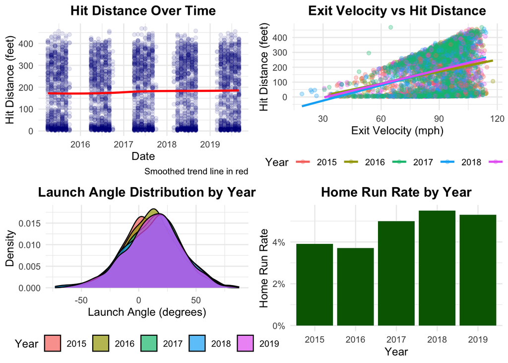

```r
plot_trends(df)
```

```r
additional_analyses(df)
```

```
## [1] "Seasonal Effect on Hit Distance:"
##
## Call:
## lm(formula = hit_distance ~ year + season, data = df)
##
## Residuals:
##     Min      1Q  Median      3Q     Max
## -187.71 -150.57    9.77  124.08  291.89
##
## Coefficients:
##                Estimate Std. Error t value Pr(>|t|)
## (Intercept)  -7416.4270  2912.3398  -2.547  0.01091 *
## year             3.7647     1.4439   2.607  0.00916 **
## seasonSpring     5.9855     6.0680   0.986  0.32399
## seasonSummer    -0.4327     5.6927  -0.076  0.93941
## ---
## Signif. codes:  0 '***' 0.001 '**' 0.01 '*' 0.05 '.' 0.1 ' ' 1
##
## Residual standard error: 137.8 on 4518 degrees of freedom
##   (478 observations deleted due to missingness)
## Multiple R-squared:  0.001991,   Adjusted R-squared:  0.001328
## F-statistic: 3.004 on 3 and 4518 DF,  p-value: 0.02923
##
## [1] "Pitch Type Effect on Hit Distance:"
##
## Call:
## lm(formula = hit_distance ~ year + pitch_type, data = df)
##
## Residuals:
##      Min       1Q   Median       3Q      Max
## -199.511 -138.087    5.062  120.510  316.114
##
## Coefficients:
##               Estimate Std. Error t value Pr(>|t|)
## (Intercept)  -4239.685   2888.310  -1.468    0.142
## year             2.200      1.432   1.536    0.124
## pitch_typeFT   -45.578      4.119 -11.065   <2e-16 ***
## ---
## Signif. codes:  0 '***' 0.001 '**' 0.01 '*' 0.05 '.' 0.1 ' ' 1
##
```

[output cut: 77 more lines]

```
##      Min       1Q   Median       3Q      Max
## -218.286 -149.203    9.761  124.959  295.438
##
## Coefficients:
##               Estimate Std. Error t value Pr(>|t|)
## (Intercept) -7.636e+03  2.909e+03  -2.625  0.00870 **
## year         3.874e+00  1.442e+00   2.686  0.00725 **
## hit_bearing  2.500e-01  7.598e-02   3.290  0.00101 **
## ---
## Signif. codes:  0 '***' 0.001 '**' 0.01 '*' 0.05 '.' 0.1 ' ' 1
##
## Residual standard error: 137.7 on 4519 degrees of freedom
##   (478 observations deleted due to missingness)
## Multiple R-squared:  0.003916,   Adjusted R-squared:  0.003475
## F-statistic: 8.883 on 2 and 4519 DF,  p-value: 0.0001411
```

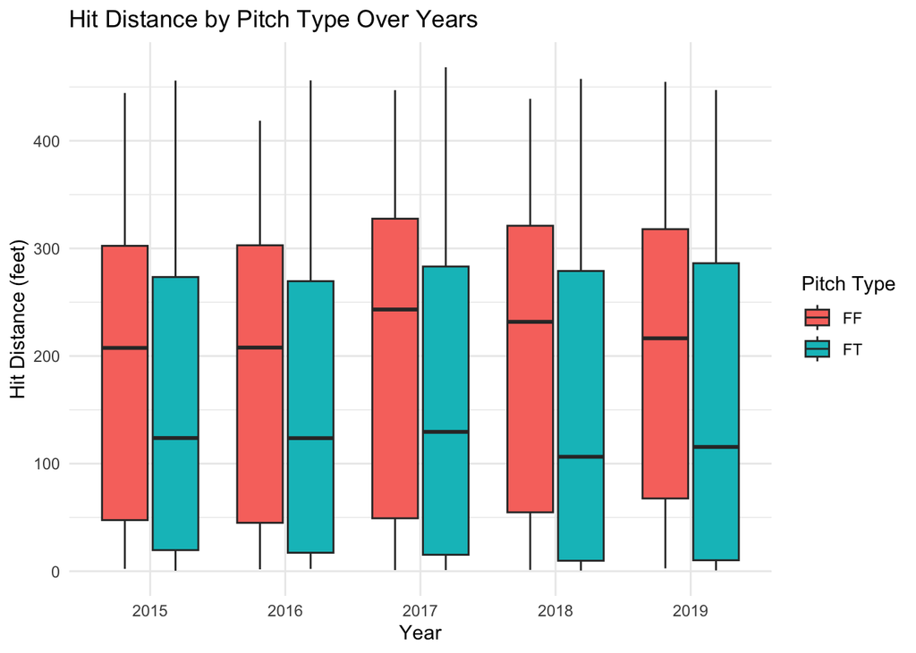

```r
df_clustered <- cluster_analysis(df)
```

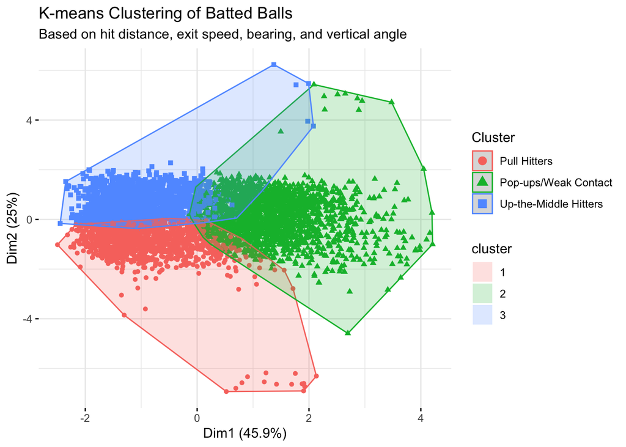

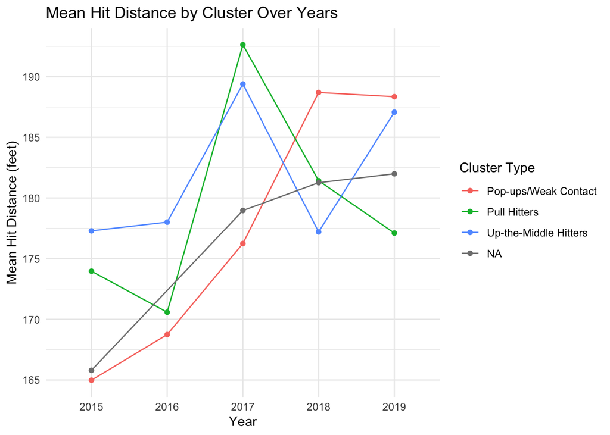

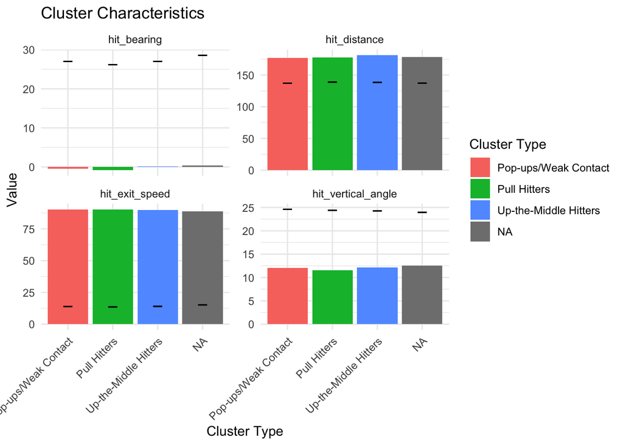